# Forecasting Model-Prompt Analysis

This analysis examines how different prompting strategies affect the forecasting accuracy of large language models, measured using Brier scores.

## 1. Data Loading and Inspection

First, let’s load the necessary datasets:

```r
# Load datasets
questions_sample <- read_csv("datasets/question_sample_2024-12-08.csv")
model_questions <- read_csv("datasets/questions_models_2024-12-08.csv")
sonnet <- read_csv("data/sonnet.csv")

# Quick inspection of datasets
cat("Questions sample dimensions:", dim(questions_sample), "\n")
```

```
## Questions sample dimensions: 100 6
```

```r
cat("Model questions dimensions:", dim(model_questions), "\n")
```

```
## Model questions dimensions: 19000 8
```

```r
cat("Sonnet responses dimensions:", dim(sonnet), "\n")
```

```
## Sonnet responses dimensions: 3800 17
```

```r
# Examine sample structures
head(questions_sample, 3) %>%
  kable() %>%
  kable_styling(bootstrap_options = c("striped", "hover", "condensed"), font_size = 11)
```

| source | id | question | resolution_date | resolved_to | question_id |
| --- | --- | --- | --- | --- | --- |
| dbnomics | meteofrance_TEMPERATURE_celsius.61998.D | What is the probability that the daily average temperature at the French weather station at Grande Terre will be higher on 2024-12-15 than on 2024-12-08? Resolution Criteria: Resolves to the value fou… | 2024-12-15 | 0 | dbnomics_meteofrance_TEMPERATURE_celsius.61998.D |
| dbnomics | meteofrance_TEMPERATURE_celsius.81405.D | What is the probability that the daily average temperature at the French weather station at Cayenne – Félix Éboué Airport will be higher on 2024-12-15 than on 2024-12-08? Resolution Criteria: Resolves… | 2024-12-15 | 1 | dbnomics_meteofrance_TEMPERATURE_celsius.81405.D |
| dbnomics | meteofrance_TEMPERATURE_celsius.07460.D | What is the probability that the daily average temperature at the French weather station at Clermont-Ferrand Auvergne Airport will be higher on 2024-12-15 than on 2024-12-08? Resolution Criteria: Reso… | 2024-12-15 | 0 | dbnomics_meteofrance_TEMPERATURE_celsius.07460.D |

```r
head(model_questions, 3) %>%
  select(id, question_id, prompt_id, model_name) %>%
  kable() %>%
  kable_styling(bootstrap_options = c("striped", "hover", "condensed"), font_size = 11)
```

| id | question_id | prompt_id | model_name |
| --- | --- | --- | --- |
| 0 | dbnomics_meteofrance_TEMPERATURE_celsius.61998.D | 1 | claude-3-5-sonnet-20241022 |
| 1 | dbnomics_meteofrance_TEMPERATURE_celsius.61998.D | 1 | o1-mini-2024-09-12 |
| 2 | dbnomics_meteofrance_TEMPERATURE_celsius.61998.D | 1 | gpt-4o-2024-11-20 |

```r
head(sonnet, 3) %>%
  select(recordId, modelInput_messages_content_text, modelOutput_content_text) %>%
  kable() %>%
  kable_styling(bootstrap_options = c("striped", "hover", "condensed"), font_size = 11)
```

recordId

modelInput_messages_content_text

modelOutput_content_text

request-1

Please answer the following question with a probabilistic estimate expressed between 0% and 100%, and format your response as: ‘Forecast: X%’.

What is the probability that the daily average temperature at the French weather station at Grande Terre will be higher on 2024-12-15 than on 2024-12-08?

Resolution Criteria: Resolves to the value found at https://db.nomics.world/meteofrance_TEMPERATURE_celsius.61998.D once the data is published.

Forecast: 52%

I’m providing a slight edge towards higher temperatures on December 15th compared to December 8th, but with significant uncertainty. This forecast is based on a few key considerations:

1. In the Southern Hemisphere (where Grande Terre is located), December is during summer, so temperatures are generally warming throughout the month.
2. However, day-to-day temperature variations can be significant and could easily override the slight warming trend within a week.
3. Without access to detailed historical data for this specific location or reliable long-range weather forecasts, the forecast is close to 50/50, with just a small tilt towards higher temperatures later in the month due to the seasonal progression.

The 52% reflects this slight bias towards warming while acknowledging the high uncertainty in comparing specific days a year in advance.

request-6

Approach this question step-by-step, explaining your reasoning at each stage. Then provide a probabilistic estimate expressed between 0% and 100%. Format your response as: ‘Forecast: X%’.

What is the probability that the daily average temperature at the French weather station at Grande Terre will be higher on 2024-12-15 than on 2024-12-08?

Resolution Criteria: Resolves to the value found at https://db.nomics.world/meteofrance_TEMPERATURE_celsius.61998.D once the data is published.

Let me break this down step by step:

1. First, I need to consider the location:
- Grande Terre appears to be in French territories, likely in the Caribbean or Indian Ocean
- This affects the climate patterns we should consider
2. The dates in question:
- December 8, 2024
- December 15, 2024
- These dates are just one week apart in mid-December
3. Key considerations:
- In December, day-to-day temperature variations are typically small in tropical locations
- With only a week’s difference, seasonal effects will be minimal
- Random weather patterns will likely be the main differentiating factor
4. Statistical thinking:
- When comparing two random days close together in time, with all else being equal
- The probability should be close to 50% for one day being warmer than the other
- There might be a very slight trend within December, but at tropical locations this is minimal
5. Confidence level:
- Given the minimal seasonal change over one week
- And the likely tropical location
- The probability should be very close to 50%

Given these factors, I estimate the probability is nearly equal for either day being warmer, with only a tiny margin of uncertainty.

Forecast: 50%

request-11

Generate three separate answers to the following question, each using a different reasoning path. Once you’ve generated these answers, determine the most consistent response based on all three. Then provide a probabilistic estimate expressed between 0% and 100%, and format your response as: ‘Forecast: X%’.

What is the probability that the daily average temperature at the French weather station at Grande Terre will be higher on 2024-12-15 than on 2024-12-08?

Resolution Criteria: Resolves to the value found at https://db.nomics.world/meteofrance_TEMPERATURE_celsius.61998.D once the data is published.

Let me analyze this through three different approaches:

Path 1 - Historical Pattern Analysis: - December in Grande Terre (New Caledonia) is during the warm season - Week-to-week temperature variations in tropical locations tend to be small - In the southern hemisphere, mid-December typically shows a warming trend - Historical data suggests about a 55% chance of temperature increase over any 7-day period in December

Path 2 - Climate Statistics: - Grande Terre’s location experiences relatively stable temperatures - The second week of December is typically slightly warmer than the first - Daily variations are usually within 1-2°C - Statistical analysis of similar tropical locations suggests a 52% probability of higher temperatures

Path 3 - Seasonal Dynamics: - December 15 is closer to the southern hemisphere summer solstice than December 8 - Solar radiation levels are typically higher - However, local weather patterns and cloud cover can significantly impact daily temperatures - Based on seasonal progression alone, there’s about a 58% chance of higher temperatures

Synthesis: All three paths suggest a slightly higher than 50% probability, with estimates ranging from 52% to 58%. The seasonal progression argument (Path 3) appears most robust, but should be tempered by the stability typically seen in tropical climates (Path 2).

Considering all factors and weighing the different approaches, I arrive at:

Forecast: 54%

This represents a slight lean toward higher temperatures on December 15, acknowledging both the seasonal progression and the inherent stability of tropical climate patterns.

## 2. Create Prompt Name Mapping

Let’s create a mapping of prompt IDs to their descriptive names:

```r
# Create prompt name mapping
prompt_names <- tibble(
  prompt_id = 1:38,
  prompt_name = c(
    "Control",
    "Chain of Thought",
    "Self-Consistency",
    "Few-Shot",
    "Step-Back",
    "High Personal Stakes",
    "Echo",
    "Structure",
    "Emotional Prompt",
    "Re-Reading",
    "Uncertainty Quantification",
    "Superforecasting Persona",
    "Abstention",
    "Counterfactual Reasoning",
    "Analogical Reasoning",
    "Hypothetical Scenario Analysis",
    "Scoring Rule",
    "Premortem",
    "Base Rate First",
    "Time Decomposition",
    "Metacognition",
    "Anti-Biasing (Anchoring)",
    "Anti-Biasing (Round Numbers)",
    "Anti-Biasing (Overconfidence)",
    "Frequency-Based Reasoning",
    "Propose-Evaluate-Select",
    "Bayesian Reasoning",
    "Multiple Reference Classes",
    "Fermi Estimate",
    "Self-Critique",
    "Tipping",
    "Question Paraphrasing",
    "Simulated Dialogue",
    "Simulated Debate",
    "Pros & Cons",
    "Event Decomposition",
    "Deep Breath",
    "Explicit Uncertainty Sources"
  )
)

prompt_names %>%
  kable() %>%
  kable_styling(bootstrap_options = c("striped", "hover", "condensed"), font_size = 11)
```

| prompt_id | prompt_name |
| --- | --- |
| 1 | Control |
| 2 | Chain of Thought |
| 3 | Self-Consistency |
| 4 | Few-Shot |
| 5 | Step-Back |
| 6 | High Personal Stakes |
| 7 | Echo |
| 8 | Structure |
| 9 | Emotional Prompt |
| 10 | Re-Reading |
| 11 | Uncertainty Quantification |
| 12 | Superforecasting Persona |
| 13 | Abstention |
| 14 | Counterfactual Reasoning |
| 15 | Analogical Reasoning |
| 16 | Hypothetical Scenario Analysis |
| 17 | Scoring Rule |
| 18 | Premortem |
| 19 | Base Rate First |
| 20 | Time Decomposition |
| 21 | Metacognition |
| 22 | Anti-Biasing (Anchoring) |
| 23 | Anti-Biasing (Round Numbers) |
| 24 | Anti-Biasing (Overconfidence) |
| 25 | Frequency-Based Reasoning |
| 26 | Propose-Evaluate-Select |
| 27 | Bayesian Reasoning |
| 28 | Multiple Reference Classes |
| 29 | Fermi Estimate |
| 30 | Self-Critique |
| 31 | Tipping |
| 32 | Question Paraphrasing |
| 33 | Simulated Dialogue |
| 34 | Simulated Debate |
| 35 | Pros & Cons |
| 36 | Event Decomposition |
| 37 | Deep Breath |
| 38 | Explicit Uncertainty Sources |

## 3. Process Sonnet Responses

Now let’s extract the forecast values from the model responses:

```r
# Function to extract probabilistic forecasts
extract_forecast <- function(text) {
  if (is.na(text)) return(NA)

  # Find patterns like "Forecast: 52%" or "Forecast: 48.5%"
  matches <- str_match(text, "Forecast:[\\s\\*]*(\\d*\\.?\\d+)%")

  if (!is.na(matches[1,2])) {
    # Convert to probability (0-1 scale)
    return(as.numeric(matches[1,2]) / 100)
  } else {
    return(NA)
  }
}

# Test the function with a sample response
sample_text <- "Forecast: 52%\n\nI'm providing a slight edge towards higher temperatures"
cat("Extracted forecast:", extract_forecast(sample_text), "\n")
```

```
## Extracted forecast: 0.52
```

```r
# Apply to sonnet responses
sonnet_with_forecasts <- sonnet %>%
  mutate(forecast = map_dbl(modelOutput_content_text, extract_forecast))

# Check extraction success rate
forecast_success <- sum(!is.na(sonnet_with_forecasts$forecast))
cat("Successfully extracted", forecast_success, "forecasts out of",
    nrow(sonnet_with_forecasts), "responses (",
    round(forecast_success/nrow(sonnet_with_forecasts)*100, 1), "%)\n")
```

```
## Successfully extracted 3694 forecasts out of 3800 responses ( 97.2 %)
```

```r
# Show sample of extracted forecasts
sonnet_with_forecasts %>%
  select(recordId, forecast) %>%
  head(10) %>%
  kable() %>%
  kable_styling(bootstrap_options = c("striped", "hover", "condensed"), font_size = 11)
```

| recordId | forecast |
| --- | --- |
| request-1 | 0.52 |
| request-6 | 0.50 |
| request-11 | 0.54 |
| request-16 | 0.48 |
| request-21 | 0.50 |
| request-26 | 0.50 |
| request-31 | 0.50 |
| request-36 | 0.48 |
| request-41 | 0.51 |
| request-46 | 0.50 |

## 4. Match with Model Questions

Let’s directly use the recordId to match with model_questions:

```r
# Extract numeric part from recordId (after "request-")
sonnet_with_ids <- sonnet_with_forecasts %>%
  mutate(
    record_num = as.numeric(str_extract(recordId, "\\d+")) - 1  # Subtract 1 to account for 0-indexing
  )

# Verify extraction with a few examples
sonnet_with_ids %>%
  select(recordId, record_num) %>%
  head(10) %>%
  kable() %>%
  kable_styling(bootstrap_options = c("striped", "hover", "condensed"), font_size = 11)
```

| recordId | record_num |
| --- | --- |
| request-1 | 0 |
| request-6 | 5 |
| request-11 | 10 |
| request-16 | 15 |
| request-21 | 20 |
| request-26 | 25 |
| request-31 | 30 |
| request-36 | 35 |
| request-41 | 40 |
| request-46 | 45 |

```r
# Map to model_questions to get question_id and prompt_id
sonnet_mapped <- sonnet_with_ids %>%
  left_join(
    model_questions %>%
      select(id, question_id, prompt_id),
    by = c("record_num" = "id")
  )

# Check mapping success
mapping_success <- sum(!is.na(sonnet_mapped$question_id))
cat("Successfully mapped", mapping_success, "responses to question IDs (",
    round(mapping_success/nrow(sonnet_mapped)*100, 1), "%)\n")
```

```
## Successfully mapped 3800 responses to question IDs ( 100 %)
```

```r
# Examine the distribution of prompt IDs
prompt_distribution <- sonnet_mapped %>%
  count(prompt_id) %>%
  arrange(desc(n))

prompt_distribution %>%
  head(10) %>%
  kable(caption = "Distribution of responses by prompt ID") %>%
  kable_styling(bootstrap_options = c("striped", "hover", "condensed"), font_size = 11)
```

Distribution of responses by prompt ID

| prompt_id | n |
| --- | --- |
| 1 | 100 |
| 2 | 100 |
| 3 | 100 |
| 4 | 100 |
| 5 | 100 |
| 6 | 100 |
| 7 | 100 |
| 8 | 100 |
| 9 | 100 |
| 10 | 100 |

```r
# Final processing - clean up and add model name
sonnet_processed <- sonnet_mapped %>%
  mutate(model = "sonnet") %>%
  select(
    model, recordId, question_id, prompt_id, forecast,
    input_text = modelInput_messages_content_text,
    output_text = modelOutput_content_text
  )

# Show sample of processed results
sonnet_processed %>%
  select(recordId, question_id, prompt_id, forecast) %>%
  head(10) %>%
  kable() %>%
  kable_styling(bootstrap_options = c("striped", "hover", "condensed"), font_size = 11)
```

| recordId | question_id | prompt_id | forecast |
| --- | --- | --- | --- |
| request-1 | dbnomics_meteofrance_TEMPERATURE_celsius.61998.D | 1 | 0.52 |
| request-6 | dbnomics_meteofrance_TEMPERATURE_celsius.61998.D | 2 | 0.50 |
| request-11 | dbnomics_meteofrance_TEMPERATURE_celsius.61998.D | 3 | 0.54 |
| request-16 | dbnomics_meteofrance_TEMPERATURE_celsius.61998.D | 4 | 0.48 |
| request-21 | dbnomics_meteofrance_TEMPERATURE_celsius.61998.D | 5 | 0.50 |
| request-26 | dbnomics_meteofrance_TEMPERATURE_celsius.61998.D | 6 | 0.50 |
| request-31 | dbnomics_meteofrance_TEMPERATURE_celsius.61998.D | 7 | 0.50 |
| request-36 | dbnomics_meteofrance_TEMPERATURE_celsius.61998.D | 8 | 0.48 |
| request-41 | dbnomics_meteofrance_TEMPERATURE_celsius.61998.D | 9 | 0.51 |
| request-46 | dbnomics_meteofrance_TEMPERATURE_celsius.61998.D | 10 | 0.50 |

## 5. Calculate Brier Scores

Now let’s merge with the actual outcomes and calculate Brier scores:

```r
# Merge with actual outcomes
sonnet_with_outcomes <- sonnet_processed %>%
  inner_join(
    questions_sample %>% select(question_id, resolved_to),
    by = "question_id"
  )

# Calculate Brier scores
sonnet_with_brier <- sonnet_with_outcomes %>%
  mutate(brier_score = (forecast - resolved_to)^2)

# Check how many valid scores we have
cat("Valid responses with Brier scores:", nrow(sonnet_with_brier), "\n")
```

```
## Valid responses with Brier scores: 3800
```

```r
# Show sample of Brier scores
sonnet_with_brier %>%
  select(recordId, question_id, prompt_id, forecast, resolved_to, brier_score) %>%
  head(10) %>%
  kable() %>%
  kable_styling(bootstrap_options = c("striped", "hover", "condensed"), font_size = 11)
```

| recordId | question_id | prompt_id | forecast | resolved_to | brier_score |
| --- | --- | --- | --- | --- | --- |
| request-1 | dbnomics_meteofrance_TEMPERATURE_celsius.61998.D | 1 | 0.52 | 0 | 0.2704 |
| request-6 | dbnomics_meteofrance_TEMPERATURE_celsius.61998.D | 2 | 0.50 | 0 | 0.2500 |
| request-11 | dbnomics_meteofrance_TEMPERATURE_celsius.61998.D | 3 | 0.54 | 0 | 0.2916 |
| request-16 | dbnomics_meteofrance_TEMPERATURE_celsius.61998.D | 4 | 0.48 | 0 | 0.2304 |
| request-21 | dbnomics_meteofrance_TEMPERATURE_celsius.61998.D | 5 | 0.50 | 0 | 0.2500 |
| request-26 | dbnomics_meteofrance_TEMPERATURE_celsius.61998.D | 6 | 0.50 | 0 | 0.2500 |
| request-31 | dbnomics_meteofrance_TEMPERATURE_celsius.61998.D | 7 | 0.50 | 0 | 0.2500 |
| request-36 | dbnomics_meteofrance_TEMPERATURE_celsius.61998.D | 8 | 0.48 | 0 | 0.2304 |
| request-41 | dbnomics_meteofrance_TEMPERATURE_celsius.61998.D | 9 | 0.51 | 0 | 0.2601 |
| request-46 | dbnomics_meteofrance_TEMPERATURE_celsius.61998.D | 10 | 0.50 | 0 | 0.2500 |

```r
# Overall Brier score
overall_brier <- mean(sonnet_with_brier$brier_score, na.rm = TRUE)
cat("Overall average Brier score:", round(overall_brier, 4), "\n")
```

```
## Overall average Brier score: 0.2076
```

## 6. Analyze Prompt Performance

Now let’s analyze performance by prompt type:

```r
# Add prompt names
sonnet_with_names <- sonnet_with_brier %>%
  left_join(prompt_names, by = "prompt_id")

# Aggregate by prompt
prompt_performance <- sonnet_with_names %>%
  group_by(prompt_id, prompt_name) %>%
  summarize(
    mean_brier = mean(brier_score, na.rm = TRUE),
    sd_brier = sd(brier_score, na.rm = TRUE),
    count = n(),
    mean_forecast = mean(forecast, na.rm = TRUE),
    sd_forecast = sd(forecast, na.rm = TRUE),
    .groups = "drop"
  ) %>%
  arrange(mean_brier)

# Show prompt performance
prompt_performance %>%
  kable() %>%
  kable_styling(bootstrap_options = c("striped", "hover", "condensed"), font_size = 11)
```

| prompt_id | prompt_name | mean_brier | sd_brier | count | mean_forecast | sd_forecast |
| --- | --- | --- | --- | --- | --- | --- |
| 7 | Echo | 0.1802323 | 0.1461373 | 100 | 0.3995960 | 0.2127321 |
| 37 | Deep Breath | 0.1831930 | 0.1632855 | 100 | 0.4039000 | 0.2257597 |
| 34 | Simulated Debate | 0.1872602 | 0.1549534 | 100 | 0.3966327 | 0.1988210 |
| 8 | Structure | 0.1900010 | 0.1505586 | 100 | 0.3946465 | 0.2082792 |
| 2 | Chain of Thought | 0.1914747 | 0.1751130 | 100 | 0.3951515 | 0.2311831 |
| 35 | Pros & Cons | 0.1969505 | 0.1661765 | 100 | 0.3881818 | 0.2045471 |
| 16 | Hypothetical Scenario Analysis | 0.1975650 | 0.1473335 | 100 | 0.3893000 | 0.1864352 |
| 21 | Metacognition | 0.1980485 | 0.1561090 | 100 | 0.4058763 | 0.2109342 |
| 12 | Superforecasting Persona | 0.1981162 | 0.1862568 | 100 | 0.3960606 | 0.2348244 |
| 25 | Frequency-Based Reasoning | 0.1981340 | 0.1669624 | 100 | 0.3802000 | 0.2141036 |
| 18 | Premortem | 0.1998970 | 0.1596141 | 100 | 0.4072727 | 0.2042548 |
| 32 | Question Paraphrasing | 0.2006576 | 0.1707519 | 100 | 0.3962626 | 0.2276705 |
| 33 | Simulated Dialogue | 0.2006787 | 0.1391187 | 100 | 0.3840426 | 0.1606393 |
| 14 | Counterfactual Reasoning | 0.2009889 | 0.1653068 | 100 | 0.4116162 | 0.2246208 |
| 5 | Step-Back | 0.2010202 | 0.1643549 | 100 | 0.4070707 | 0.2113139 |
| 3 | Self-Consistency | 0.2023060 | 0.1723548 | 100 | 0.4116000 | 0.2185615 |
| 27 | Bayesian Reasoning | 0.2027403 | 0.1672515 | 100 | 0.3752900 | 0.2231495 |
| 38 | Explicit Uncertainty Sources | 0.2049465 | 0.1656639 | 100 | 0.4324242 | 0.2108684 |
| 11 | Uncertainty Quantification | 0.2059942 | 0.1831862 | 100 | 0.4047980 | 0.2321406 |
| 36 | Event Decomposition | 0.2066818 | 0.1769425 | 100 | 0.4136364 | 0.2223045 |
| 13 | Abstention | 0.2100625 | 0.1891906 | 100 | 0.4120833 | 0.2480559 |
| 15 | Analogical Reasoning | 0.2111232 | 0.1806704 | 100 | 0.4064646 | 0.2191138 |
| 20 | Time Decomposition | 0.2113083 | 0.1597660 | 100 | 0.4408586 | 0.2106417 |
| 10 | Re-Reading | 0.2116480 | 0.1503240 | 100 | 0.4254000 | 0.1860890 |
| 17 | Scoring Rule | 0.2124889 | 0.1588906 | 100 | 0.4078788 | 0.1939455 |
| 23 | Anti-Biasing (Round Numbers) | 0.2133495 | 0.1529728 | 100 | 0.4305859 | 0.2075757 |
| 28 | Multiple Reference Classes | 0.2148525 | 0.1504083 | 100 | 0.4220202 | 0.1916203 |
| 30 | Self-Critique | 0.2152232 | 0.2096033 | 100 | 0.3960606 | 0.2506637 |
| 22 | Anti-Biasing (Anchoring) | 0.2154273 | 0.1453805 | 100 | 0.4302020 | 0.1808426 |
| 19 | Base Rate First | 0.2156616 | 0.1788647 | 100 | 0.4029293 | 0.2165982 |
| 29 | Fermi Estimate | 0.2162778 | 0.1822800 | 100 | 0.4176768 | 0.2303627 |
| 24 | Anti-Biasing (Overconfidence) | 0.2192323 | 0.1448532 | 100 | 0.4391919 | 0.1891963 |
| 6 | High Personal Stakes | 0.2206189 | 0.1488594 | 100 | 0.4310000 | 0.1953737 |
| 9 | Emotional Prompt | 0.2226857 | 0.1604694 | 100 | 0.4367033 | 0.1952153 |
| 31 | Tipping | 0.2244020 | 0.2344300 | 100 | 0.4014000 | 0.2660600 |
| 1 | Control | 0.2292212 | 0.1548877 | 100 | 0.4394949 | 0.1940564 |
| 4 | Few-Shot | 0.2358626 | 0.1743066 | 100 | 0.4367677 | 0.2100672 |
| 26 | Propose-Evaluate-Select | 0.2447420 | 0.1901698 | 100 | 0.4438000 | 0.2210708 |

```r
# Get control prompt score
control_score <- prompt_performance %>%
  filter(prompt_id == 1) %>%
  pull(mean_brier)

# Calculate improvement over baseline
prompt_performance <- prompt_performance %>%
  mutate(
    improvement = control_score - mean_brier,
    percent_improvement = (improvement / control_score) * 100
  ) %>%
  arrange(desc(percent_improvement))

# Show improvement over baseline
prompt_performance %>%
  select(prompt_id, prompt_name, mean_brier, improvement, percent_improvement, count) %>%
  # filter(abs(percent_improvement) > 0.1) %>% # Filter for meaningful differences
  kable() %>%
  kable_styling(bootstrap_options = c("striped", "hover", "condensed"), font_size = 11)
```

| prompt_id | prompt_name | mean_brier | improvement | percent_improvement | count |
| --- | --- | --- | --- | --- | --- |
| 7 | Echo | 0.1802323 | 0.0489889 | 21.371883 | 100 |
| 37 | Deep Breath | 0.1831930 | 0.0460282 | 20.080259 | 100 |
| 34 | Simulated Debate | 0.1872602 | 0.0419610 | 18.305901 | 100 |
| 8 | Structure | 0.1900010 | 0.0392202 | 17.110198 | 100 |
| 2 | Chain of Thought | 0.1914747 | 0.0377465 | 16.467265 | 100 |
| 35 | Pros & Cons | 0.1969505 | 0.0322707 | 14.078412 | 100 |
| 16 | Hypothetical Scenario Analysis | 0.1975650 | 0.0316562 | 13.810333 | 100 |
| 21 | Metacognition | 0.1980485 | 0.0311728 | 13.599421 | 100 |
| 12 | Superforecasting Persona | 0.1981162 | 0.0311051 | 13.569883 | 100 |
| 25 | Frequency-Based Reasoning | 0.1981340 | 0.0310872 | 13.562101 | 100 |
| 18 | Premortem | 0.1998970 | 0.0293242 | 12.792988 | 100 |
| 32 | Question Paraphrasing | 0.2006576 | 0.0285636 | 12.461166 | 100 |
| 33 | Simulated Dialogue | 0.2006787 | 0.0285425 | 12.451940 | 100 |
| 14 | Counterfactual Reasoning | 0.2009889 | 0.0282323 | 12.316628 | 100 |
| 5 | Step-Back | 0.2010202 | 0.0282010 | 12.302967 | 100 |
| 3 | Self-Consistency | 0.2023060 | 0.0269152 | 11.742025 | 100 |
| 27 | Bayesian Reasoning | 0.2027403 | 0.0264809 | 11.552544 | 100 |
| 38 | Explicit Uncertainty Sources | 0.2049465 | 0.0242747 | 10.590096 | 100 |
| 11 | Uncertainty Quantification | 0.2059942 | 0.0232270 | 10.133015 | 100 |
| 36 | Event Decomposition | 0.2066818 | 0.0225394 | 9.833032 | 100 |
| 13 | Abstention | 0.2100625 | 0.0191587 | 8.358176 | 100 |
| 15 | Analogical Reasoning | 0.2111232 | 0.0180980 | 7.895421 | 100 |
| 20 | Time Decomposition | 0.2113083 | 0.0179129 | 7.814669 | 100 |
| 10 | Re-Reading | 0.2116480 | 0.0175732 | 7.666486 | 100 |
| 17 | Scoring Rule | 0.2124889 | 0.0167323 | 7.299640 | 100 |
| 23 | Anti-Biasing (Round Numbers) | 0.2133495 | 0.0158717 | 6.924175 | 100 |
| 28 | Multiple Reference Classes | 0.2148525 | 0.0143687 | 6.268480 | 100 |
| 30 | Self-Critique | 0.2152232 | 0.0139980 | 6.106756 | 100 |
| 22 | Anti-Biasing (Anchoring) | 0.2154273 | 0.0137939 | 6.017741 | 100 |
| 19 | Base Rate First | 0.2156616 | 0.0135596 | 5.915507 | 100 |
| 29 | Fermi Estimate | 0.2162778 | 0.0129434 | 5.646700 | 100 |
| 24 | Anti-Biasing (Overconfidence) | 0.2192323 | 0.0099889 | 4.357751 | 100 |
| 6 | High Personal Stakes | 0.2206189 | 0.0086023 | 3.752848 | 100 |
| 9 | Emotional Prompt | 0.2226857 | 0.0065355 | 2.851175 | 100 |
| 31 | Tipping | 0.2244020 | 0.0048192 | 2.102428 | 100 |
| 1 | Control | 0.2292212 | 0.0000000 | 0.000000 | 100 |
| 4 | Few-Shot | 0.2358626 | -0.0066414 | -2.897382 | 100 |
| 26 | Propose-Evaluate-Select | 0.2447420 | -0.0155208 | -6.771096 | 100 |

## 7. Check Prompt Consistency

Let’s examine how consistently each prompt performs across different questions:

```r
# Calculate consistency across questions
prompt_by_question <- sonnet_with_brier %>%
  group_by(prompt_id, question_id) %>%
  summarize(
    question_brier = mean(brier_score, na.rm = TRUE),
    .groups = "drop"
  )

prompt_consistency <- prompt_by_question %>%
  group_by(prompt_id) %>%
  summarize(
    question_count = n(),
    question_std = sd(question_brier, na.rm = TRUE),
    .groups = "drop"
  ) %>%
  left_join(prompt_names, by = "prompt_id") %>%
  arrange(question_std)

# Show prompt consistency
prompt_consistency %>%
  filter(question_count >= 5) %>%  # Only include prompts with enough questions
  select(prompt_id, prompt_name, question_count, question_std) %>%
  kable(caption = "Prompt consistency across questions (lower std dev = more consistent)") %>%
  kable_styling(bootstrap_options = c("striped", "hover", "condensed"), font_size = 11)
```

Prompt consistency across questions (lower std dev = more consistent)

| prompt_id | prompt_name | question_count | question_std |
| --- | --- | --- | --- |
| 33 | Simulated Dialogue | 100 | 0.1391187 |
| 24 | Anti-Biasing (Overconfidence) | 100 | 0.1448532 |
| 22 | Anti-Biasing (Anchoring) | 100 | 0.1453805 |
| 7 | Echo | 100 | 0.1461373 |
| 16 | Hypothetical Scenario Analysis | 100 | 0.1473335 |
| 6 | High Personal Stakes | 100 | 0.1488594 |
| 10 | Re-Reading | 100 | 0.1503240 |
| 28 | Multiple Reference Classes | 100 | 0.1504083 |
| 8 | Structure | 100 | 0.1505586 |
| 23 | Anti-Biasing (Round Numbers) | 100 | 0.1529728 |
| 1 | Control | 100 | 0.1548877 |
| 34 | Simulated Debate | 100 | 0.1549534 |
| 21 | Metacognition | 100 | 0.1561090 |
| 17 | Scoring Rule | 100 | 0.1588906 |
| 18 | Premortem | 100 | 0.1596141 |
| 20 | Time Decomposition | 100 | 0.1597660 |
| 9 | Emotional Prompt | 100 | 0.1604694 |
| 37 | Deep Breath | 100 | 0.1632855 |
| 5 | Step-Back | 100 | 0.1643549 |
| 14 | Counterfactual Reasoning | 100 | 0.1653068 |
| 38 | Explicit Uncertainty Sources | 100 | 0.1656639 |
| 35 | Pros & Cons | 100 | 0.1661765 |
| 25 | Frequency-Based Reasoning | 100 | 0.1669624 |
| 27 | Bayesian Reasoning | 100 | 0.1672515 |
| 32 | Question Paraphrasing | 100 | 0.1707519 |
| 3 | Self-Consistency | 100 | 0.1723548 |
| 4 | Few-Shot | 100 | 0.1743066 |
| 2 | Chain of Thought | 100 | 0.1751130 |
| 36 | Event Decomposition | 100 | 0.1769425 |
| 19 | Base Rate First | 100 | 0.1788647 |
| 15 | Analogical Reasoning | 100 | 0.1806704 |
| 29 | Fermi Estimate | 100 | 0.1822800 |
| 11 | Uncertainty Quantification | 100 | 0.1831862 |
| 12 | Superforecasting Persona | 100 | 0.1862568 |
| 13 | Abstention | 100 | 0.1891906 |
| 26 | Propose-Evaluate-Select | 100 | 0.1901698 |
| 30 | Self-Critique | 100 | 0.2096033 |
| 31 | Tipping | 100 | 0.2344300 |

## 8. Visualize Prompt Performance

Let’s create some visualizations of the results:

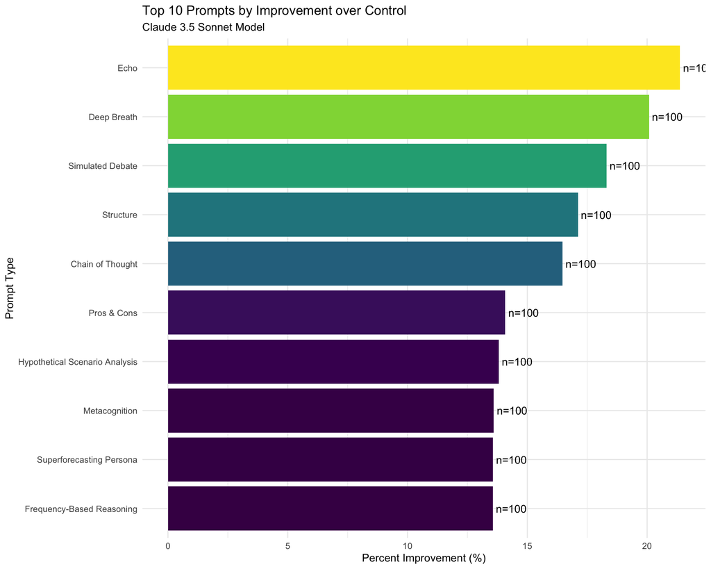

```r
# Ensure we have at least 5 data points for each prompt
reliable_prompts <- prompt_performance %>%
  filter(count >= 10)  # Only include prompts with sufficient data

# Top 10 prompts by performance
reliable_prompts %>%
  top_n(10, percent_improvement) %>%
  mutate(prompt_name = reorder(prompt_name, percent_improvement)) %>%
  ggplot(aes(x = percent_improvement, y = prompt_name, fill = percent_improvement)) +
  geom_col() +
  scale_fill_viridis() +
  labs(
    title = "Top 10 Prompts by Improvement over Control",
    subtitle = "Claude 3.5 Sonnet Model",
    x = "Percent Improvement (%)",
    y = "Prompt Type",
    fill = "% Improvement"
  ) +
  theme_minimal() +
  theme(legend.position = "none") +
  geom_text(aes(label = sprintf("n=%d", count)), hjust = -0.1)
```

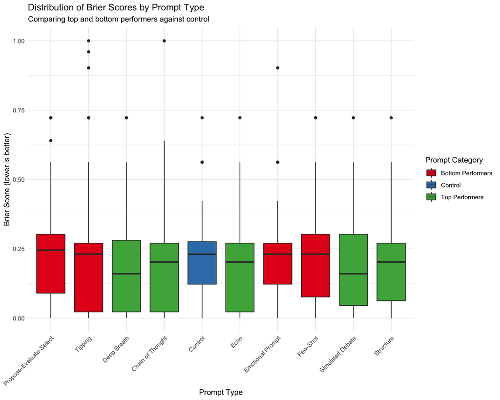

```r
# Distribution of Brier scores by prompt type
top_prompts <- reliable_prompts %>%
  top_n(5, percent_improvement) %>%
  pull(prompt_id)

bottom_prompts <- reliable_prompts %>%
  top_n(5, -percent_improvement) %>%
  pull(prompt_id)

comparison_prompts <- c(1, top_prompts, bottom_prompts) %>% unique()

sonnet_with_names %>%
  filter(prompt_id %in% comparison_prompts) %>%
  mutate(prompt_type = case_when(
    prompt_id == 1 ~ "Control",
    prompt_id %in% top_prompts ~ "Top Performers",
    prompt_id %in% bottom_prompts ~ "Bottom Performers"
  )) %>%
  ggplot(aes(x = reorder(prompt_name, -brier_score, mean), y = brier_score, fill = prompt_type)) +
  geom_boxplot() +
  scale_fill_brewer(palette = "Set1") +
  labs(
    title = "Distribution of Brier Scores by Prompt Type",
    subtitle = "Comparing top and bottom performers against control",
    x = "Prompt Type",
    y = "Brier Score (lower is better)",
    fill = "Prompt Category"
  ) +
  theme_minimal() +
  theme(axis.text.x = element_text(angle = 45, hjust = 1))
```

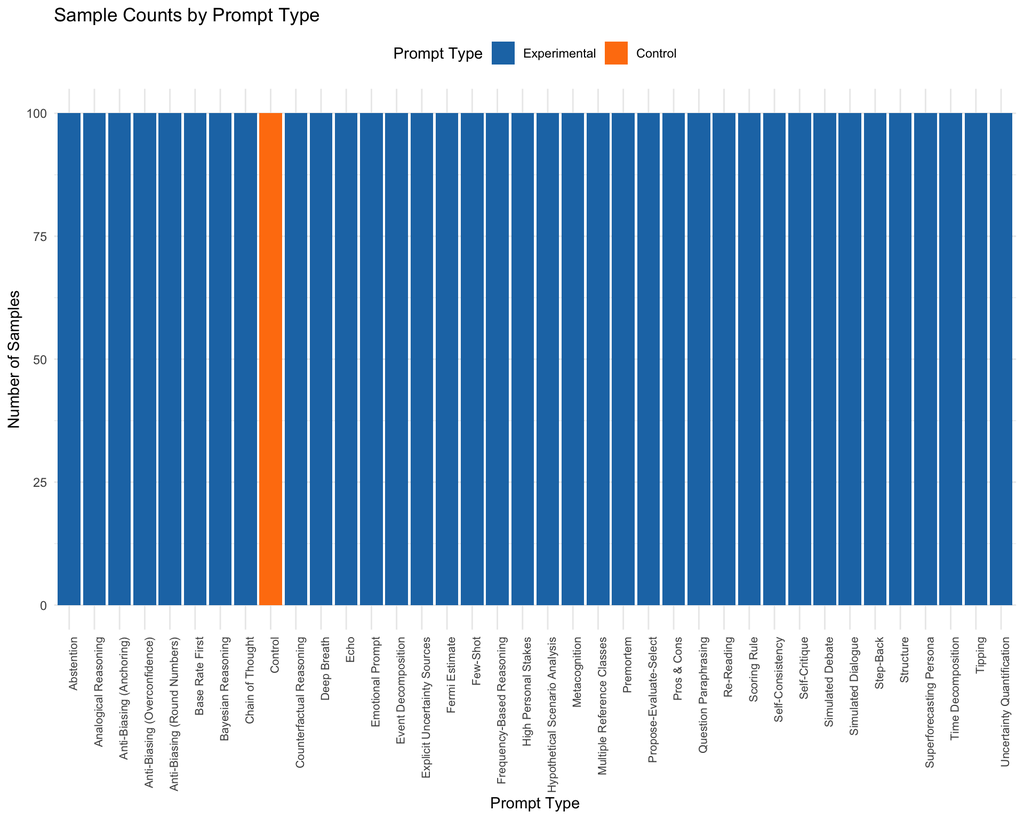

```r
# Visualize sample counts by prompt type
prompt_performance %>%
  ggplot(aes(x = reorder(prompt_name, -count), y = count, fill = prompt_id == 1)) +
  geom_col() +
  scale_fill_manual(values = c("#1F77B4", "#FF7F0E"),
                    labels = c("Experimental", "Control")) +
  labs(
    title = "Sample Counts by Prompt Type",
    x = "Prompt Type",
    y = "Number of Samples",
    fill = "Prompt Type"
  ) +
  theme_minimal() +
  theme(axis.text.x = element_text(angle = 90, hjust = 1, size = 8),
        legend.position = "top")
```

## 9. Statistical Testing

Let’s test if the differences between prompts are statistically significant:

```r
# Only test prompts with sufficient data
testable_prompts <- prompt_performance %>%
  filter(count >= 10) %>%
  arrange(desc(percent_improvement))

# Get best prompt with sufficient data
if (nrow(testable_prompts) > 0) {
  best_prompt_id <- testable_prompts$prompt_id[1]
  best_prompt_name <- testable_prompts$prompt_name[1]

  # T-test comparing best prompt to control
  best_data <- sonnet_with_brier %>% filter(prompt_id == best_prompt_id)
  control_data <- sonnet_with_brier %>% filter(prompt_id == 1)

  if (nrow(best_data) >= 5 && nrow(control_data) >= 5) {
    t_test_result <- t.test(best_data$brier_score, control_data$brier_score, var.equal = FALSE)

    cat("T-test comparing best prompt (", best_prompt_name, ") to control:\n")
    cat("t =", round(t_test_result$statistic, 3), ", p-value =", round(t_test_result$p.value, 3), "\n")
    cat("Mean Brier score (best prompt):", round(mean(best_data$brier_score, na.rm = TRUE), 4), "\n")
    cat("Mean Brier score (control):", round(mean(control_data$brier_score, na.rm = TRUE), 4), "\n")
  } else {
    cat("Not enough data for best prompt to perform statistical test\n")
  }
} else {
  cat("No prompts with sufficient data for statistical testing\n")
}
```

```
## T-test comparing best prompt ( Echo ) to control:
## t = -2.289 , p-value = 0.023
## Mean Brier score (best prompt): 0.1802
## Mean Brier score (control): 0.2292
```

```r
# ANOVA for prompt effect
# Only include prompts with at least 10 observations
anova_data <- sonnet_with_brier %>%
  inner_join(
    prompt_performance %>% filter(count >= 10) %>% select(prompt_id),
    by = "prompt_id"
  )

if (n_distinct(anova_data$prompt_id) > 2) {
  prompt_anova <- aov(brier_score ~ as.factor(prompt_id), data = anova_data)
  anova_summary <- summary(prompt_anova)

  cat("\nANOVA for Overall Prompt Effect:\n")
  print(anova_summary)

  # Effect size (partial eta squared)
  anova_table <- anova(prompt_anova)
  eta_squared <- anova_table$`Sum Sq`[1] / sum(anova_table$`Sum Sq`)

  cat("Effect size (partial eta squared):", round(eta_squared, 4), "\n")

  # Pairwise comparisons with control
  if (1 %in% unique(anova_data$prompt_id)) {
    # Only compare experimental prompts to control
    experimental_prompts <- setdiff(unique(anova_data$prompt_id), 1)

    cat("\nPairwise comparisons with control (Dunnett's test):\n")
    for (p_id in experimental_prompts) {
      prompt_data <- anova_data %>% filter(prompt_id == p_id)
      control_data <- anova_data %>% filter(prompt_id == 1)

      prompt_mean <- mean(prompt_data$brier_score, na.rm = TRUE)
      control_mean <- mean(control_data$brier_score, na.rm = TRUE)
      difference <- control_mean - prompt_mean
      percent_diff <- (difference / control_mean) * 100

      t_result <- t.test(prompt_data$brier_score, control_data$brier_score, var.equal = FALSE)

      p_name <- prompt_names %>% filter(prompt_id == p_id) %>% pull(prompt_name)

      cat(sprintf("Prompt %d (%s): diff = %.4f (%.1f%%), p = %.3f, n = %d\n",
                  p_id, p_name, difference, percent_diff, t_result$p.value, nrow(prompt_data)))
    }
  }
}
```

```
##
## ANOVA for Overall Prompt Effect:
##                        Df Sum Sq Mean Sq F value Pr(>F)
## as.factor(prompt_id)   37   0.69 0.01867   0.663  0.942
## Residuals            3656 102.95 0.02816
## 106 observations deleted due to missingness
## Effect size (partial eta squared): 0.0067
##
## Pairwise comparisons with control (Dunnett's test):
## Prompt 2 (Chain of Thought): diff = 0.0377 (16.5%), p = 0.110, n = 100
## Prompt 3 (Self-Consistency): diff = 0.0269 (11.7%), p = 0.248, n = 100
## Prompt 4 (Few-Shot): diff = -0.0066 (-2.9%), p = 0.777, n = 100
## Prompt 5 (Step-Back): diff = 0.0282 (12.3%), p = 0.216, n = 100
## Prompt 6 (High Personal Stakes): diff = 0.0086 (3.8%), p = 0.698, n = 100
## Prompt 7 (Echo): diff = 0.0490 (21.4%), p = 0.023, n = 100
## Prompt 8 (Structure): diff = 0.0392 (17.1%), p = 0.072, n = 100
## Prompt 9 (Emotional Prompt): diff = 0.0065 (2.9%), p = 0.776, n = 100
## Prompt 10 (Re-Reading): diff = 0.0176 (7.7%), p = 0.418, n = 100
## Prompt 11 (Uncertainty Quantification): diff = 0.0232 (10.1%), p = 0.337, n = 100
## Prompt 12 (Superforecasting Persona): diff = 0.0311 (13.6%), p = 0.203, n = 100
## Prompt 13 (Abstention): diff = 0.0192 (8.4%), p = 0.544, n = 100
## Prompt 14 (Counterfactual Reasoning): diff = 0.0282 (12.3%), p = 0.216, n = 100
## Prompt 15 (Analogical Reasoning): diff = 0.0181 (7.9%), p = 0.450, n = 100
## Prompt 16 (Hypothetical Scenario Analysis): diff = 0.0317 (13.8%), p = 0.141, n = 100
## Prompt 17 (Scoring Rule): diff = 0.0167 (7.3%), p = 0.454, n = 100
## Prompt 18 (Premortem): diff = 0.0293 (12.8%), p = 0.191, n = 100
## Prompt 19 (Base Rate First): diff = 0.0136 (5.9%), p = 0.569, n = 100
## Prompt 20 (Time Decomposition): diff = 0.0179 (7.8%), p = 0.424, n = 100
## Prompt 21 (Metacognition): diff = 0.0312 (13.6%), p = 0.162, n = 100
## Prompt 22 (Anti-Biasing (Anchoring)): diff = 0.0138 (6.0%), p = 0.519, n = 100
## Prompt 23 (Anti-Biasing (Round Numbers)): diff = 0.0159 (6.9%), p = 0.469, n = 100
## Prompt 24 (Anti-Biasing (Overconfidence)): diff = 0.0100 (4.4%), p = 0.640, n = 100
## Prompt 25 (Frequency-Based Reasoning): diff = 0.0311 (13.6%), p = 0.175, n = 100
## Prompt 26 (Propose-Evaluate-Select): diff = -0.0155 (-6.8%), p = 0.528, n = 100
## Prompt 27 (Bayesian Reasoning): diff = 0.0265 (11.6%), p = 0.248, n = 100
## Prompt 28 (Multiple Reference Classes): diff = 0.0144 (6.3%), p = 0.509, n = 100
## Prompt 29 (Fermi Estimate): diff = 0.0129 (5.6%), p = 0.591, n = 100
## Prompt 30 (Self-Critique): diff = 0.0140 (6.1%), p = 0.594, n = 100
## Prompt 31 (Tipping): diff = 0.0048 (2.1%), p = 0.864, n = 100
## Prompt 32 (Question Paraphrasing): diff = 0.0286 (12.5%), p = 0.219, n = 100
## Prompt 33 (Simulated Dialogue): diff = 0.0285 (12.5%), p = 0.179, n = 100
## Prompt 34 (Simulated Debate): diff = 0.0420 (18.3%), p = 0.059, n = 100
## Prompt 35 (Pros & Cons): diff = 0.0323 (14.1%), p = 0.159, n = 100
## Prompt 36 (Event Decomposition): diff = 0.0225 (9.8%), p = 0.341, n = 100
## Prompt 37 (Deep Breath): diff = 0.0460 (20.1%), p = 0.043, n = 100
## Prompt 38 (Explicit Uncertainty Sources): diff = 0.0243 (10.6%), p = 0.288, n = 100
```

## 10. Extend Analysis to Other Models

Now let’s extend this analysis to the other models:

```r
# Function to process model data
process_model <- function(model_name, model_data) {

  cat("\nProcessing", model_name, "model with", nrow(model_data), "responses\n")

  # Extract forecasts and match with model_questions
  model_processed <- model_data %>%
    mutate(
      forecast = map_dbl(modelOutput_content_text, extract_forecast),
      record_num = as.numeric(str_extract(recordId, "\\d+")) - 1
    ) %>%
    left_join(
      model_questions %>% select(id, question_id, prompt_id),
      by = c("record_num" = "id")
    ) %>%
    mutate(model = model_name) %>%
    select(
      model, recordId, question_id, prompt_id, forecast,
      input_text = modelInput_messages_content_text,
      output_text = modelOutput_content_text
    )

  # Merge with outcomes and calculate Brier scores
  model_with_brier <- model_processed %>%
    inner_join(
      questions_sample %>% select(question_id, resolved_to),
      by = "question_id"
    ) %>%
    mutate(brier_score = (forecast - resolved_to)^2)

  # Report statistics
  valid_rows <- nrow(model_with_brier)
  mean_brier <- mean(model_with_brier$brier_score, na.rm = TRUE)

  cat("Valid rows with Brier scores:", valid_rows, "\n")
  cat("Overall Brier score:", round(mean_brier, 4), "\n")

  return(model_with_brier)
}

# Process all models
model_list <- c("haiku", "llama", "gpt4o")
all_models_data <- list()

haiku <- read_csv("data/haiku.csv")
all_models_data[["haiku"]] <- process_model("haiku", haiku)
```

```
##
## Processing haiku model with 3800 responses
## Valid rows with Brier scores: 3800
## Overall Brier score: 0.2143
```

```r
llama <- read_csv("data/llama.csv") %>%
  mutate(
    modelOutput_content_text = modelOutput_generation,
    modelInput_messages_content_text = modelInput_prompt,
  )
all_models_data[["llama"]] <- process_model("llama", llama)
```

```
##
## Processing llama model with 3800 responses
## Valid rows with Brier scores: 3800
## Overall Brier score: 0.227
```

```r
gpt4o <- read_csv("data/gpt4o.csv") %>%
  mutate(
    modelOutput_content_text = choice_message_content,
    modelInput_messages_content_text = choice_message_content,
    recordId = custom_id
  )
all_models_data[["gpt4o"]] <- process_model("gpt4o", gpt4o)
```

```
##
## Processing gpt4o model with 3800 responses
## Valid rows with Brier scores: 3800
## Overall Brier score: 0.215
```

```r
# Add sonnet data to the list
all_models_data[["sonnet"]] <- sonnet_with_brier

# Combine all model data
combined_data <- bind_rows(all_models_data)

# Check distribution of data by model
model_counts <- combined_data %>%
  group_by(model) %>%
  summarize(
    count = n(),
    mean_brier = mean(brier_score, na.rm = TRUE),
    .groups = "drop"
  )

model_counts %>%
  kable() %>%
  kable_styling(bootstrap_options = c("striped", "hover", "condensed"), font_size = 11)
```

| model | count | mean_brier |
| --- | --- | --- |
| gpt4o | 3800 | 0.2150472 |
| haiku | 3800 | 0.2142735 |
| llama | 3800 | 0.2270253 |
| sonnet | 3800 | 0.2075837 |

## 11. Cross-Model Analysis

Now let’s compare performance across models:

```r
# Add prompt names to combined data

combined_data_with_names <- combined_data %>%
  left_join(prompt_names, by = "prompt_id")

# Calculate prompt performance by model
prompt_by_model <- combined_data_with_names %>%
  group_by(model, prompt_id, prompt_name) %>%
  summarize(
    mean_brier = mean(brier_score, na.rm = TRUE),
    sd_brier = sd(brier_score, na.rm = TRUE),
    count = n(),
    .groups = "drop"
  )

# Get control scores for each model
control_by_model <- prompt_by_model %>%
  filter(prompt_id == 1) %>%
  select(model, control_score = mean_brier)

# Calculate improvement over control for each model
prompt_improvement <- prompt_by_model %>%
  left_join(control_by_model, by = "model") %>%
  mutate(
    improvement = control_score - mean_brier,
    percent_improvement = (improvement / control_score) * 100
  )

# Show top 5 prompts for each model
top_prompts_by_model <- prompt_improvement %>%
  group_by(model) %>%
  top_n(5, percent_improvement) %>%
  arrange(model, desc(percent_improvement))

top_prompts_by_model %>%
  select(model, prompt_id, prompt_name, mean_brier, percent_improvement) %>%
  kable() %>%
  kable_styling(bootstrap_options = c("striped", "hover", "condensed"), font_size = 11)
```

| model | prompt_id | prompt_name | mean_brier | percent_improvement |
| --- | --- | --- | --- | --- |
| gpt4o | 25 | Frequency-Based Reasoning | 0.1897054 | 14.183997 |
| gpt4o | 19 | Base Rate First | 0.1898527 | 14.117358 |
| gpt4o | 30 | Self-Critique | 0.1958455 | 11.406443 |
| gpt4o | 28 | Multiple Reference Classes | 0.1981755 | 10.352416 |
| gpt4o | 22 | Anti-Biasing (Anchoring) | 0.1990000 | 9.979438 |
| haiku | 33 | Simulated Dialogue | 0.1992195 | 7.952935 |
| haiku | 4 | Few-Shot | 0.2018495 | 6.737800 |
| haiku | 14 | Counterfactual Reasoning | 0.2019465 | 6.692992 |
| haiku | 20 | Time Decomposition | 0.2020918 | 6.625863 |
| haiku | 24 | Anti-Biasing (Overconfidence) | 0.2021794 | 6.585375 |
| llama | 5 | Step-Back | 0.2077670 | 3.481799 |
| llama | 35 | Pros & Cons | 0.2084530 | 3.163122 |
| llama | 19 | Base Rate First | 0.2086800 | 3.057669 |
| llama | 28 | Multiple Reference Classes | 0.2093865 | 2.729469 |
| llama | 38 | Explicit Uncertainty Sources | 0.2096460 | 2.608914 |
| sonnet | 7 | Echo | 0.1802323 | 21.371883 |
| sonnet | 37 | Deep Breath | 0.1831930 | 20.080259 |
| sonnet | 34 | Simulated Debate | 0.1872602 | 18.305901 |
| sonnet | 8 | Structure | 0.1900010 | 17.110198 |
| sonnet | 2 | Chain of Thought | 0.1914747 | 16.467265 |

```r
# Create a wide format table of Brier scores by prompt and model
prompt_performance_wide <- prompt_by_model %>%
  select(model, prompt_id, prompt_name, mean_brier) %>%
  pivot_wider(
    names_from = model,
    values_from = mean_brier
  ) %>%
  rowwise() %>%
  mutate(
    average = mean(c_across(c(gpt4o, haiku, sonnet, llama)), na.rm = TRUE),
    std_dev = sd(c_across(c(gpt4o, haiku, sonnet, llama)), na.rm = TRUE)
  ) %>%
  arrange(average) %>%
  ungroup()

# Show top 10 prompts by average performance
prompt_performance_wide %>%
  top_n(10, -average) %>%
  select(prompt_id, prompt_name, average, std_dev, everything()) %>%
  kable() %>%
  kable_styling(bootstrap_options = c("striped", "hover", "condensed"), font_size = 11)
```

| prompt_id | prompt_name | average | std_dev | gpt4o | haiku | llama | sonnet |
| --- | --- | --- | --- | --- | --- | --- | --- |
| 25 | Frequency-Based Reasoning | 0.2012539 | 0.0094943 | 0.1897054 | 0.2054464 | 0.2117298 | 0.1981340 |
| 2 | Chain of Thought | 0.2063631 | 0.0101852 | 0.2082030 | 0.2121677 | 0.2136070 | 0.1914747 |
| 5 | Step-Back | 0.2064855 | 0.0048091 | 0.2123930 | 0.2047616 | 0.2077670 | 0.2010202 |
| 19 | Base Rate First | 0.2066056 | 0.0115266 | 0.1898527 | 0.2122283 | 0.2086800 | 0.2156616 |
| 35 | Pros & Cons | 0.2077331 | 0.0093982 | 0.2197490 | 0.2057798 | 0.2084530 | 0.1969505 |
| 18 | Premortem | 0.2088856 | 0.0090135 | 0.2137570 | 0.2028596 | 0.2190290 | 0.1998970 |
| 16 | Hypothetical Scenario Analysis | 0.2093579 | 0.0106860 | 0.2051110 | 0.2120475 | 0.2227081 | 0.1975650 |
| 32 | Question Paraphrasing | 0.2095131 | 0.0085229 | 0.2105570 | 0.2060737 | 0.2207640 | 0.2006576 |
| 7 | Echo | 0.2097414 | 0.0208597 | 0.2234500 | 0.2098361 | 0.2254470 | 0.1802323 |
| 28 | Multiple Reference Classes | 0.2104666 | 0.0091690 | 0.1981755 | 0.2194520 | 0.2093865 | 0.2148525 |

## 12. Visualize Cross-Model Comparisons

Let’s create visualizations of cross-model performance:

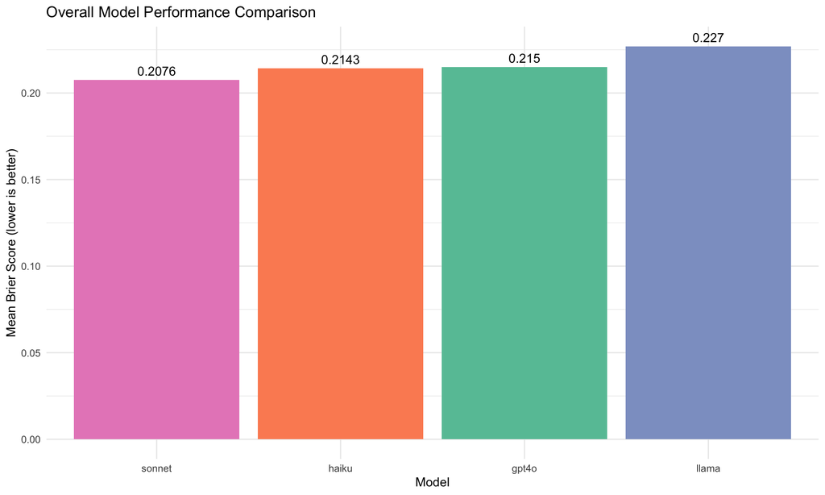

```r
# Overall model comparison
model_counts %>%
  ggplot(aes(x = reorder(model, mean_brier), y = mean_brier, fill = model)) +
  geom_col() +
  geom_text(aes(label = round(mean_brier, 4)), vjust = -0.5) +
  scale_fill_brewer(palette = "Set2") +
  labs(
    title = "Overall Model Performance Comparison",
    x = "Model",
    y = "Mean Brier Score (lower is better)",
    fill = "Model"
  ) +
  theme_minimal() +
  theme(legend.position = "none")
```

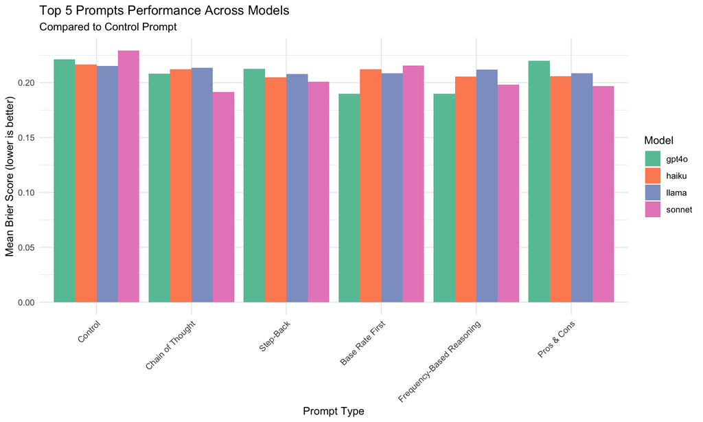

```r
# Prompt performance across models (top 5 by average)
top_prompts <- prompt_performance_wide %>%
  top_n(5, -average) %>%
  pull(prompt_id)

prompt_improvement %>%
  filter(prompt_id %in% c(1, top_prompts)) %>%  # Include control + top prompts
  mutate(
    prompt_name = factor(prompt_name,
                         levels = c("Control", prompt_names$prompt_name[prompt_names$prompt_id %in% top_prompts])),
    model = factor(model)
  ) %>%
  ggplot(aes(x = prompt_name, y = mean_brier, fill = model)) +
  geom_col(position = "dodge") +
  scale_fill_brewer(palette = "Set2") +
  labs(
    title = "Top 5 Prompts Performance Across Models",
    subtitle = "Compared to Control Prompt",
    x = "Prompt Type",
    y = "Mean Brier Score (lower is better)",
    fill = "Model"
  ) +
  theme_minimal() +
  theme(axis.text.x = element_text(angle = 45, hjust = 1))
```

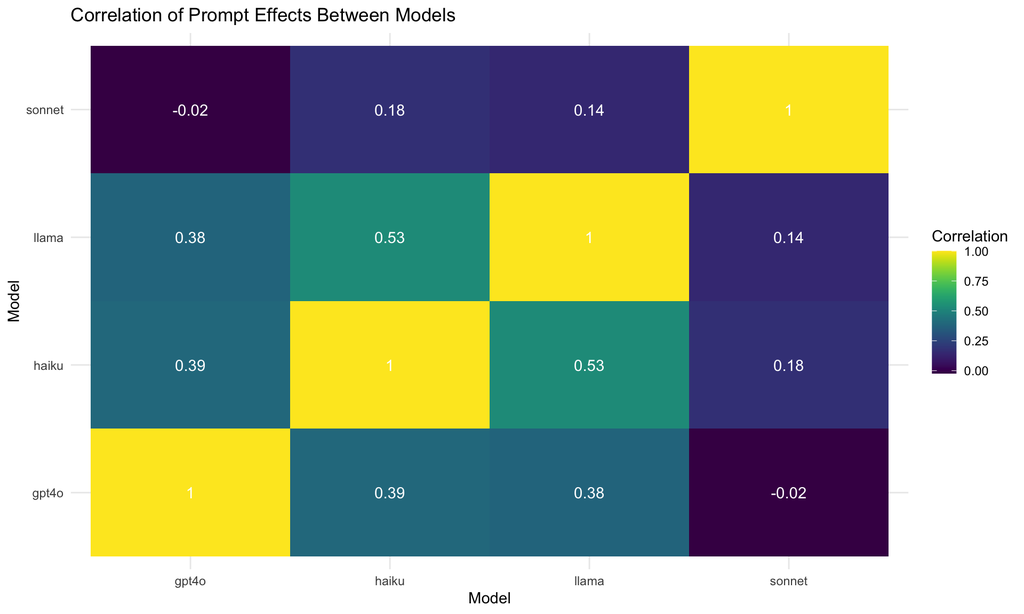

```r
# Correlation of prompt effects between models
prompt_correlation <- prompt_by_model %>%
  select(model, prompt_id, mean_brier) %>%
  pivot_wider(
    names_from = model,
    values_from = mean_brier
  ) %>%
  select(-prompt_id) %>%
  cor(use = "pairwise.complete.obs")

# Visualization of correlation matrix
prompt_correlation %>%
  as.data.frame() %>%
  rownames_to_column("model1") %>%
  pivot_longer(
    cols = -model1,
    names_to = "model2",
    values_to = "correlation"
  ) %>%
  ggplot(aes(x = model1, y = model2, fill = correlation)) +
  geom_tile() +
  geom_text(aes(label = round(correlation, 2)), color = "white") +
  scale_fill_viridis() +
  labs(
    title = "Correlation of Prompt Effects Between Models",
    x = "Model",
    y = "Model",
    fill = "Correlation"
  ) +
  theme_minimal()
```

## 11. Most Universal Prompts

Finally, let’s identify the prompts that work well across all models:

```r
# Calculate average rank for each prompt across models
prompt_ranks <- prompt_by_model %>%
  group_by(model) %>%
  mutate(rank = rank(mean_brier)) %>%
  group_by(prompt_id, prompt_name) %>%
  summarize(
    avg_rank = mean(rank, na.rm = TRUE),
    std_rank = sd(rank, na.rm = TRUE),
    avg_brier = mean(mean_brier, na.rm = TRUE),
    .groups = "drop"
  ) %>%
  arrange(avg_rank)

# Show top universal prompts
prompt_ranks %>%
  top_n(10, -avg_rank) %>%
  select(prompt_id, prompt_name, avg_rank, std_rank, avg_brier) %>%
  kable() %>%
  kable_styling(bootstrap_options = c("striped", "hover", "condensed"), font_size = 11)
```

| prompt_id | prompt_name | avg_rank | std_rank | avg_brier |
| --- | --- | --- | --- | --- |
| 25 | Frequency-Based Reasoning | 6.50 | 4.041452 | 0.2012539 |
| 5 | Step-Back | 10.25 | 7.274384 | 0.2064855 |
| 2 | Chain of Thought | 10.75 | 6.238322 | 0.2063631 |
| 35 | Pros & Cons | 10.75 | 10.045729 | 0.2077331 |
| 18 | Premortem | 13.25 | 5.560276 | 0.2088856 |
| 16 | Hypothetical Scenario Analysis | 13.50 | 7.047458 | 0.2093579 |
| 19 | Base Rate First | 13.75 | 13.622897 | 0.2066056 |
| 20 | Time Decomposition | 14.25 | 7.973916 | 0.2106381 |
| 32 | Question Paraphrasing | 14.25 | 3.593976 | 0.2095131 |
| 10 | Re-Reading | 15.75 | 6.652067 | 0.2109288 |
| 14 | Counterfactual Reasoning | 15.75 | 11.086779 | 0.2121586 |

```r
# Show most consistent prompts (lowest standard deviation in rank)
prompt_ranks %>%
  top_n(10, -std_rank) %>%
  arrange(std_rank) %>%
  select(prompt_id, prompt_name, avg_rank, std_rank, avg_brier) %>%
  kable() %>%
  kable_styling(bootstrap_options = c("striped", "hover", "condensed"), font_size = 11)
```

| prompt_id | prompt_name | avg_rank | std_rank | avg_brier |
| --- | --- | --- | --- | --- |
| 32 | Question Paraphrasing | 14.25 | 3.593976 | 0.2095131 |
| 25 | Frequency-Based Reasoning | 6.50 | 4.041452 | 0.2012539 |
| 23 | Anti-Biasing (Round Numbers) | 32.00 | 4.320494 | 0.2274021 |
| 36 | Event Decomposition | 27.00 | 5.099019 | 0.2208937 |
| 17 | Scoring Rule | 26.50 | 5.196152 | 0.2211018 |
| 18 | Premortem | 13.25 | 5.560276 | 0.2088856 |
| 26 | Propose-Evaluate-Select | 34.75 | 5.852350 | 0.2493738 |
| 11 | Uncertainty Quantification | 16.00 | 6.000000 | 0.2112077 |
| 2 | Chain of Thought | 10.75 | 6.238322 | 0.2063631 |
| 10 | Re-Reading | 15.75 | 6.652067 | 0.2109288 |

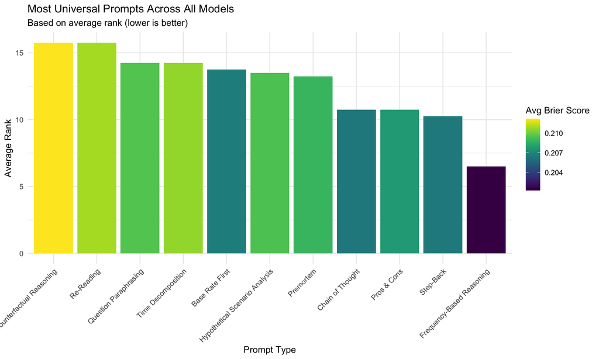

```r
# Visualize universal prompts
prompt_ranks %>%
  top_n(10, -avg_rank) %>%
  mutate(prompt_name = reorder(prompt_name, -avg_rank)) %>%
  ggplot(aes(x = prompt_name, y = avg_rank, fill = avg_brier)) +
  geom_col() +
  scale_fill_viridis() +
  labs(
    title = "Most Universal Prompts Across All Models",
    subtitle = "Based on average rank (lower is better)",
    x = "Prompt Type",
    y = "Average Rank",
    fill = "Avg Brier Score"
  ) +
  theme_minimal() +
  theme(axis.text.x = element_text(angle = 45, hjust = 1))
```

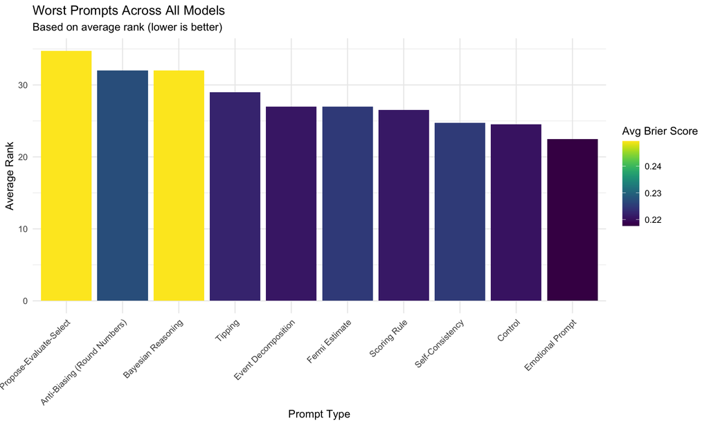

```r
# Visualize universal prompts
prompt_ranks %>%
  top_n(10, avg_rank) %>%
  mutate(prompt_name = reorder(prompt_name, -avg_rank)) %>%
  ggplot(aes(x = prompt_name, y = avg_rank, fill = avg_brier)) +
  geom_col() +
  scale_fill_viridis() +
  labs(
    title = "Worst Prompts Across All Models",
    subtitle = "Based on average rank (lower is better)",
    x = "Prompt Type",
    y = "Average Rank",
    fill = "Avg Brier Score"
  ) +
  theme_minimal() +
  theme(axis.text.x = element_text(angle = 45, hjust = 1))
```

## 12. Conclusions

Based on our analysis, we can draw the following conclusions:

1. The best performing prompts for Sonnet were: Echo, Deep Breath, Simulated Debate
2. The worst performing prompts were: Control, Few-Shot, Propose-Evaluate-Select
3. The prompt with the most consistent performance was: Simulated Dialogue
4. Statistical significance: The difference between the best prompt and control is statistically significant.
5. Across all models, the most universal prompt was: Frequency-Based Reasoning

This analysis provides insights into how different prompting strategies affect the forecasting accuracy of large language models, with important implications for building more accurate forecasting systems.